# Hoang Laura: praca domowa nr.2

autor: Hoang Laura

01/11/2021

## Wstęp

Celem tej pracy, było stworzenie własnej wersji pewnej wizualizacji, udostępnionej publicznie, w przeciągu ostatnich 2 tygodni.

Jako źródło, postanowiłam wybrać stronę https://www.gov.pl/web/koronawirus/wykaz-zarazen-koronawirusem-sars-cov-2, w której mamy dostępne dane dotyczące liczby zakażeń koronawirusem z każdego dnia. Zdecydowałam się na analizę dnia 01.11.2021.

Importujemy biblioteki:

```r
library(dplyr)
library(ggplot2)
```

Wczytujemy dane:

```r
covid_original <- read.csv("akutalne_dane_wojewodztwa.csv",
                           sep=";",
                           stringsAsFactors=TRUE)

covid <- covid_original[-c(1),]
rownames(covid) <- 1:16
covid <- arrange(covid,-liczba_przypadkow)

head(covid)
```

|  | wojewodztwo | liczba_przypadkow | liczba_na_10_tys_mieszkancow | zgony | zgony_w_wyniku_covid_bez_chorob_wspolistniejacych | zgony_w_wyniku_covid_i_chorob_wspolistniejacych | liczba_zlecen_poz | liczba_ozdrowiencow | liczba_osob_objetych_kwarantanna | liczba_wykonanych_testow | liczba_testow_z_wynikiem_pozytywnym | liczba_testow_z_wynikiem_negatywnym | liczba_pozostalych_testow | teryt | stan_rekordu_na |
| --- | --- | --- | --- | --- | --- | --- | --- | --- | --- | --- | --- | --- | --- | --- | --- |
| 1 | mazowieckie | 1154 | 2.13 | 6 | 5 | 1 | 95 | 1308 | 62013 | 5332 | 1285 | 3980 | 67 | t14 | 2021-10-31 |
| 2 | lubelskie | 658 | 3.13 | 1 | 0 | 1 | 66 | 1402 | 33615 | 2181 | 716 | 1442 | 23 | t06 | 2021-10-31 |
| 3 | zachodniopomorskie | 344 | 2.03 | 0 | 0 | 0 | 9 | 302 | 15426 | 1627 | 393 | 1220 | 14 | t32 | 2021-10-31 |
| 4 | podlaskie | 317 | 2.69 | 0 | 0 | 0 | 9 | 587 | 20041 | 1093 | 348 | 726 | 19 | t20 | 2021-10-31 |
| 5 | śląskie | 287 | 0.64 | 0 | 0 | 0 | 50 | 277 | 14074 | 2721 | 327 | 2380 | 14 | t24 | 2021-10-31 |
| 6 | łódzkie | 286 | 1.17 | 1 | 0 | 1 | 24 | 285 | 16508 | 1902 | 312 | 1582 | 8 | t10 | 2021-10-31 |

## Oryginalna wizualizacja

Pierwowzorem wizualizacji, którą utworzyłam jest niniejszy wykres:

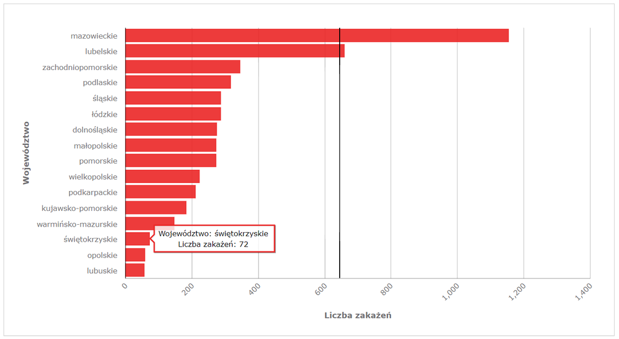

## Moja wizualizacja

Kod i utworzona wizualizacja:

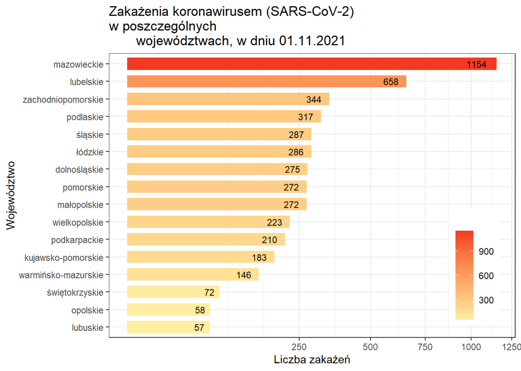

```r
p_col <- covid %>%
  ggplot( aes(x = liczba_przypadkow, y = reorder(wojewodztwo, liczba_przypadkow),
              fill = liczba_przypadkow) ) +
  geom_col(width=.7) +
  scale_fill_gradient(low = "#ffeda0", high = "#f03b20") +
  geom_text( aes(label = liczba_przypadkow), hjust = 1.5, size = 3) +
  xlab("Liczba zakażeń") +
  ylab("Województwo") +
  theme_bw() +
  scale_x_continuous(trans = "sqrt") +
  labs(title = "Zakażenia koronawirusem (SARS-CoV-2) \nw poszczególnych
       województwach, w dniu 01.11.2021", fill = "") +
  theme(legend.position = c(0.9, 0.25))

p_col
```

## Podsumowanie

W mojej wizualizacji nie zmieniłąm typu wykresu, ale poprawiłam jego czytelność i estetykę.

Ponieważ występuje duży uskok miedzy największą i najmniejszą wartością przy **liczbie zakażeń**, oryginalny wykres ma pustą przestrzeń w prawym dolnym rogu, przez co nie wygląda on estetycznie.

Dlatego, przeskalowałam oś X-ów. Zdecydowałam się na przeskalowanie o pierwiastek kwadratowy, aby zapobiec temu problemowi, ale zarazem nie psuło to czytelności wykresu (jak by się działo, gdybym dokonała skalowania o logarytm).

Oprócz tego, dodałam etykiety z wartościam na końcu każdego słupka i ustawiłam kolorystykę gradientową (wraz z legendą), która zmienia się względem wartości. Uważam, że jest to lepsze rozwiązanie niż interaktywne elementy oryginału, gdyż w tamtym wypadku etykiety i pionowa linia przeszkadzały w odczytywaniu danych i zasłaniały pozostałe słupki.